# P259: Combined data cleaning

Dendritic cells (pDC)

Kim Dill-McFarland, kadm@uw.edu

version September 09, 2020

# Background

P259.1: pDC were isolated from 4 healthy donors’ whole blood or buffy coat. Cells were adapted to media with IL3 and then cultured with eosinophil (EOS) supernatant and/or human rhinovirus (RV).

The purpose of this workflow is to complete quality control and data cleaning of metadata and RNA-seq libraries generated from the above experiments. This includes 1) removing low coverage libraries, 2) filtering rare genes, 3) removing outlying libraries, and 4) normalizing for RNA composition.

# Setup

Load packages

```r
# Data manipulation and figures
library(tidyverse)
  #Multi-panel figures
  library(cowplot)
  # Modify ggplot figures to non-overlapping text labels
  library(ggrepel)
  # Modify ggplot data order within facets
  library(drlib)
  # Plot log scales
  library(scales)
# Reading Excel files
library(readxl)
# Working with dates
library(lubridate)

# Empirical analysis of digital gene expression data
## Data normalization
library(edgeR)

# Print pretty table to knit file
library(knitr)
library(kableExtra)
  options(knitr.kable.NA = '')

#Define colors for plots
group.cols <- c("none:none"="#dadaeb",
               "none:AntiIL5"="#9e9ac8",
               "none:EOS.supp"="#54278f",
               "HRV:none"="#c7e9c0",
               "HRV:AntiIL5"="#74c476",
               "HRV:EOS.supp"="#006d2c",
               "flu:none"="#fdae6b",
               "flu:AntiIL5"="#e6550d")
samp.cols <- c("AC1"="#969696",
               "AC2"="#a6cee3",
               "AC3"="#1f78b4",
               "AC4"="#b2df8a",
               "AC5"="#33a02c",
               "AT1"="#fb9a99",
               "AT2"="#e31a1c",
               "AT3"="#fdbf6f",
               "AT4"="#ff7f00",
               "donor1"="#cab2d6",
               "donor2"="#6a3d9a",
               "donor3"="#ffff99",
               "donor4"="#b15928")
```

Set seed

```r
set.seed(4389)
```

# Read in and format data

## Counts table

Read in counts table from P259.1 and P259.2 (`data_raw/*combined_counts.csv`) and then combine to one data frame.

Read in and filter associated gene key (`data_raw/2020.06.18_HGNC.gene.key.txt`, downloaded from https://www.genenames.org/download/custom/) to protein coding (pc) genes that occur in the count data set and have valid hgnc symbols.

Then filter the count data to pc genes and save.

```r
#Save counts table
write_csv(count.pDC, "data_clean/P259_pDC_counts.csv")
```

#### Verify data order

To ensure that all data match, check that all libraries in the count data are present and in the same order in the metadata. And vice versa.

```
## [1] TRUE
```

## Sample summary

At this point, the following objects exist in our environment. Protein coding = pc

```
## [1] "count.pDC"  "group.cols" "key.pc"     "meta"       "samp.cols"
```

And the sample numbers are

| experiment | asthma | IL5 | virus | n |
| --- | --- | --- | --- | --- |
| P259_1 | healthy | none | none | 4 |
|  |  | none | HRV | 4 |
|  |  | EOS.supp | none | 3 |
|  |  | EOS.supp | HRV | 4 |
| P259_2 | asthma | none | none | 5 |
|  |  | none | HRV | 10 |
|  |  | AntiIL5 | none | 4 |
|  |  | AntiIL5 | HRV | 8 |

# Data cleaning

## Median CV coverage vs. mapped duplicate reads

Compare the median coefficient of variation (CV) coverage (`median_cv_coverage`) and percent alignment of reads with duplicates (`mapped_reads_w_dups`).

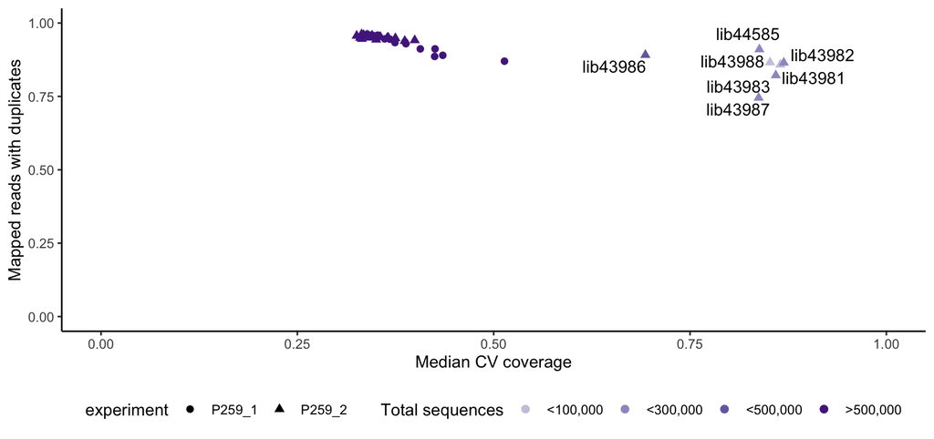

## Total aligned counts

Plot total counts per library. Here, we compare our standard cutoff of 500,000 to a less strict cutoff of 100,000, because 7 pDC libraries would be removed at the standard cutoff.

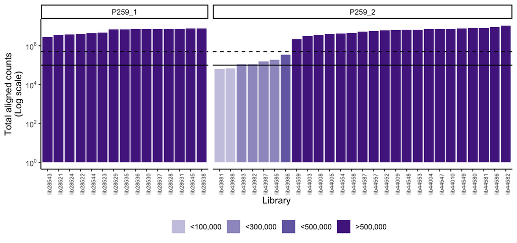

## Filter by quality and coverage

Thus, the following libraries with questionable metrics (highlighted in red in HTML format) may be removed.

| experiment | libID | donorID | asthma | IL5 | virus | median_cv_coverage | mapped_reads_w_dups | total_sequences |
| --- | --- | --- | --- | --- | --- | --- | --- | --- |
| P259_2 | lib43981 | AC1 | asthma | none | none | 0.86501 | 0.858165459 | 62823 |
| P259_2 | lib43982 | AC1 | asthma | none | HRV | 0.869398 | 0.864978903 | 113480 |
| P259_2 | lib43983 | AC1 | asthma | none | HRV | 0.85921 | 0.821943431 | 112154 |
| P259_2 | lib43986 | AC2 | asthma | none | none | 0.693137 | 0.89115488 | 347291 |
| P259_2 | lib43987 | AC2 | asthma | none | HRV | 0.837354 | 0.745407193 | 157832 |
| P259_2 | lib43988 | AC2 | asthma | none | HRV | 0.851868 | 0.865923487 | 69503 |
| P259_2 | lib44585 | AT4 | asthma | AntiIL5 | none | 0.838316 | 0.910325198 | 188722 |

```r
#Metadata
meta.filter <- meta %>%
  # CV coverage and alignment
  filter(total_sequences >= 1E5) %>%
  filter(donorID != "AC1") %>%
  droplevels()

#Count data
count.pDC.filter <- count.pDC %>%
  # Keep libraries (columns) remaining filtered metadata table (rows)
  dplyr::select(geneName, as.character(meta.filter$libID))
```

## Filter PCA outliers

Next, samples are assessed in PCA to determine if remaining questionable quality samples (labeled with libID) appear as PCA outliers.

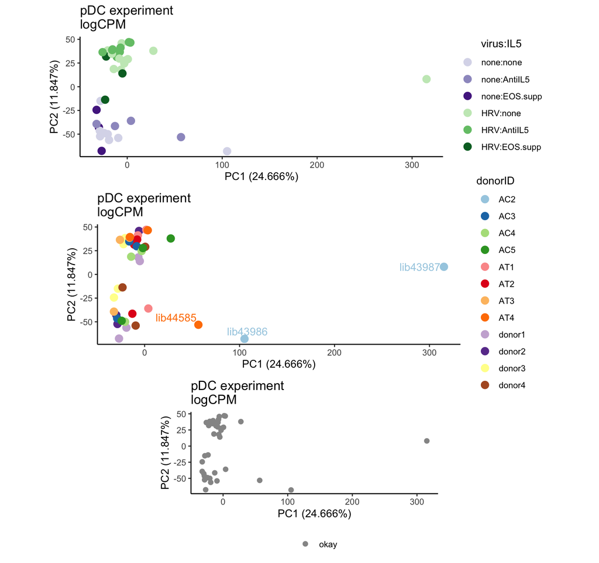

Donor AC2 appears to be an outlier for all of its samples and will be removed.

```r
#Metadata
meta.filter2 <- meta.filter %>%
  filter(donorID != "AC2") %>%
  droplevels()

#Count data
count.pDC.filter2 <- count.pDC.filter %>%
  # Keep libraries (columns) remaining filtered metadata table (rows)
  dplyr::select(geneName, as.character(meta.filter2$libID))
```

Re-assess PCA.

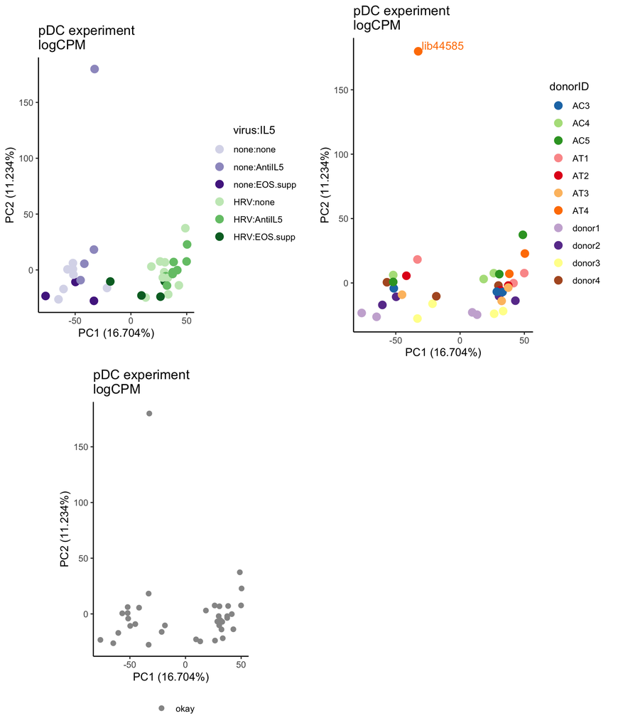

Additionally, lib44585 was flagged for poor-quality above and is labeled in the PCA. While this sample is somewhat of an outlier in PCA, it is not > 3 s.d. away from its group’s mean. Thus, it will remain and be re-assessed after gene filtering.

Therefore, the filtered data have

- max median CV coverage = 0.84
- min mapped reads with duplicates = 0.87
- min total sequences = 188,722

## Normalize for RNA composition

Create DGEList object

```r
dat.pDC.filter2 <- DGEList(
  #count table. move gene names to column names
  counts=as.matrix(column_to_rownames(count.pDC.filter2, "geneName")),
  #metadata
  samples=meta.filter2,
  #keep genes in count table
  genes=filter(key.pc, geneName %in% count.pDC.filter2$geneName))
```

## Filter rare genes

The raw gene sets contain highly variable, low abundance/rare genes. Genes must be at least 1 CPM in at least 3 samples to remain.

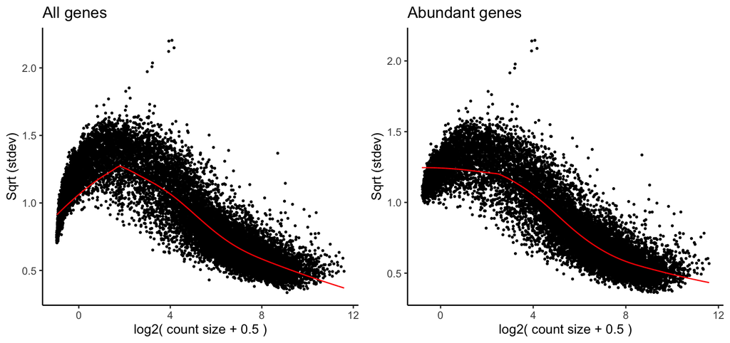

```r
source("https://raw.githubusercontent.com/kdillmcfarland/R_bioinformatic_scripts/master/RNAseq_rare_gene_filter.R")

rare.gene.filter(dat.pDC.filter2,
                 min.CPM=1,
                 min.sample=3,
                 name="dat.pDC.filter2.abund")
```

This removes 5324 (~ 28%) genes. This sufficiently filters these data as indicated by a decreasing variance trend for lowly abundant genes.

## PCA

We see that previously questionable samples (labeled with libID) are sufficiently normalized to not appear as PCA outliers.

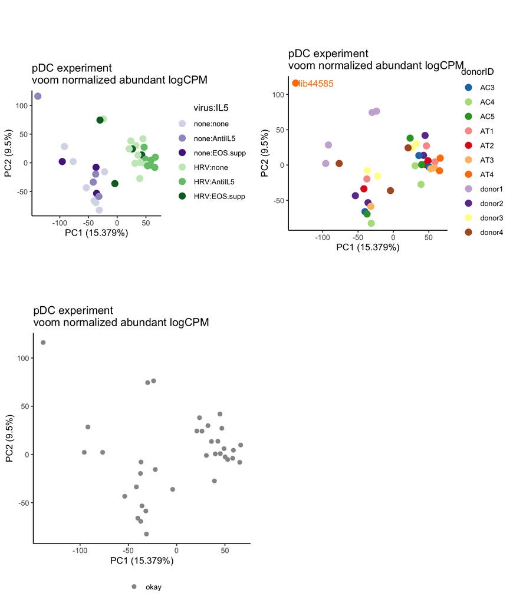

## Summary

The following final quality cutoffs were applied to the data:

- Library median CV coverage $\leq$ 0.84
- Library mapped reads with duplicates $\geq$ 0.87
- Library total counts $\geq$ 1.8872210^{5}
- Libraries from donor AC1 due to loss of media sample in previous filtering
- Within 3 sd of group mean on PCA (*e.g.* not outliers)
- Genes at least 1 CPM in at least 3 samples

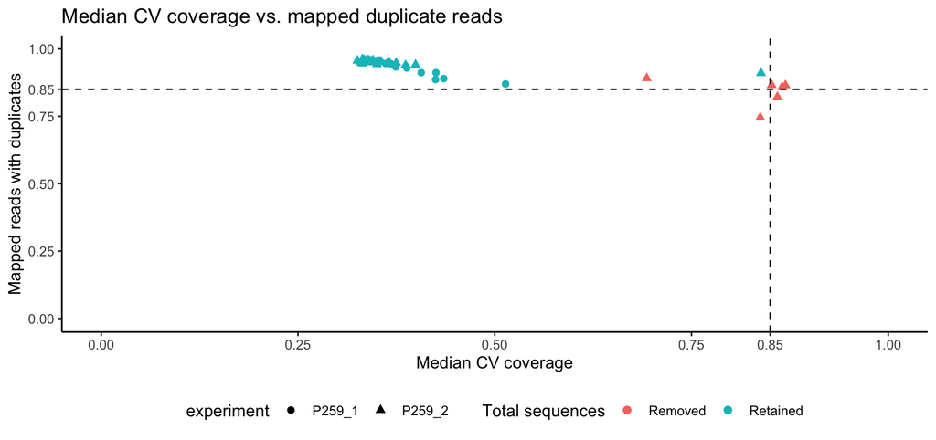

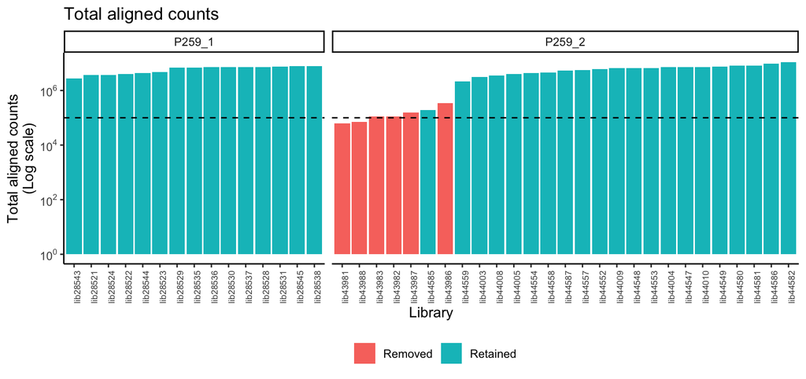

| experiment | libID | donorID | asthma | IL5 | virus | filters |
| --- | --- | --- | --- | --- | --- | --- |
| P259_2 | lib43981 | AC1 | asthma | none | none | CV coverage, total seqs |
| P259_2 | lib43983 | AC1 | asthma | none | HRV | mapped dup reads, CV coverage, no media-only sample |
| P259_2 | lib43982 | AC1 | asthma | none | HRV | CV coverage, no media-only sample |
| P259_2 | lib43986 | AC2 | asthma | none | none | PCA outlier |
| P259_2 | lib43987 | AC2 | asthma | none | HRV | mapped dup reads, PCA outlier |
| P259_2 | lib43988 | AC2 | asthma | none | HRV | CV coverage, total seqs, PCA outlier |

This results in the following samples for statistical analysis.

| experiment | asthma | IL5 | virus | n |
| --- | --- | --- | --- | --- |
| P259_1 | healthy | none | none | 4 |
|  |  | none | HRV | 4 |
|  |  | EOS.supp | none | 3 |
|  |  | EOS.supp | HRV | 4 |
| P259_2 | asthma | none | none | 3 |
|  |  | none | HRV | 6 |
|  |  | AntiIL5 | none | 4 |
|  |  | AntiIL5 | HRV | 8 |

# Save clean data

Normalized dat objects.

```r
#Save R object
#Rename all pDC object
dat.pDC.voom <- dat.pDC.filter2.abund.norm.voom

#P259_1
dat.pDC.voom_1 <- dat.pDC.voom

dat.pDC.voom_1$targets <- dat.pDC.voom_1$targets %>%
  rownames_to_column() %>%
  filter(experiment == "P259_1") %>%
  droplevels() %>%
  column_to_rownames()

dat.pDC.voom_1$E <- as.data.frame(dat.pDC.voom_1$E) %>%
  rownames_to_column() %>%
  select(rowname, dat.pDC.voom_1$targets$libID) %>%
  column_to_rownames()

#P259_2
dat.pDC.voom_2 <- dat.pDC.voom

dat.pDC.voom_2$targets <- dat.pDC.voom_2$targets %>%
  rownames_to_column() %>%
  filter(experiment == "P259_2") %>%
  droplevels() %>%
  column_to_rownames()

dat.pDC.voom_2$E <- as.data.frame(dat.pDC.voom_2$E) %>%
  rownames_to_column() %>%
  select(rowname, dat.pDC.voom_2$targets$libID) %>%
  column_to_rownames()

save(dat.pDC.voom, dat.pDC.voom_1, dat.pDC.voom_2,
     file="data_clean/P259_pDC_clean.RData")
```